# 探索性数据分析

司徒雪颖——中央财经大学

2017年11月19日

## 一、多变量建模思路描述

- 数据预处理，处理缺失值、异常值等情况
- 描述性分析，对各个变量的分布有一定了解
- 特征选择，可用过滤法删除零方差、高相关变量，用封装法挑选重要变量
- 降维，对定量数据用主成分或者因子分析等方法降维
- 训练模型

## 二、案例分析：英超数据

### （一）读入数据

从summary可以看出，很多计数变量均为右偏分布，如进球、助攻、传球、过人等自变量和下一年进球这个因变量。

```r
library(corrplot)
library(caret)
library(ggplot2)

setwd("E:/graduate/class/2017《大数据统计基础》考试题/")
soccer = read.csv("英超数据.csv")
head(soccer,3)
```

```
##       球员 年龄     球队 号码 位置 出场 首发 出场时间 进球 助攻 传球 过人
## 1     雷德   25 西汉姆联    2 后卫   36   36     3145    1    0  861    1
## 2     诺兰   31 西汉姆联    4 中场   35   35     2990   10    2 1018    9
## 3 汤姆金斯   24 西汉姆联    5 后卫   26   18     1728    1    1  634    1
##   抢断 越位 犯规 红牌 黄牌 射门 射正 射门成功率 头球进球 左脚进球 右脚进球
## 1   70    0   41    0    8   15    7 0.06666667        1        0        0
## 2   59   16   64    0    6   78   32 0.12820513        1        3        6
## 3   33    2   10    0    5   20    5 0.05000000        1        0        0
##   直接任意球进球 点球 赢得点球机会 拦截 解围 头球解围 后场解围
## 1              0    0            1   73  321      191      178
## 2              0    0            0   31   44       20       20
## 3              0    0            0   29  183       98      105
##   头球争顶成功 头球争顶失败 乌龙球 下一年进球
## 1           86            0      0          1
## 2           18            0      0          7
## 3           71            0      0          0
```

```r
dim(soccer)
```

```
## [1] 166  34
```

```r
sum(is.na(soccer))#检测有无缺失值
```

```
## [1] 0
```

```r
summary(soccer)
```

```
##        球员          年龄             球队         号码         位置
##  阿邦拉霍:  1   Min.   :20.00   曼联    :18   Min.   : 2.00   后卫:50
##  阿德巴约:  1   1st Qu.:25.00   西汉姆联:14   1st Qu.: 7.00   前锋:30
##  阿尔特塔:  1   Median :27.00   曼城    :13   Median :14.00   中场:86
##  阿格尔  :  1   Mean   :27.49   埃弗顿  :12   Mean   :14.20
##  阿圭罗  :  1   3rd Qu.:30.00   富勒姆  :12   3rd Qu.:20.75
##  阿梅奥比:  1   Max.   :40.00   切尔西  :12   Max.   :42.00
##  (Other) :160                   (Other) :85
##       出场            首发          出场时间         进球
##  Min.   : 0.00   Min.   : 0.00   Min.   :  22   Min.   : 0.000
##  1st Qu.:21.00   1st Qu.:13.25   1st Qu.:1255   1st Qu.: 1.000
##  Median :28.00   Median :24.00   Median :2136   Median : 2.000
##  Mean   :26.23   Mean   :21.84   Mean   :1969   Mean   : 3.759
##  3rd Qu.:34.00   3rd Qu.:30.75   3rd Qu.:2650   3rd Qu.: 5.000
##  Max.   :38.00   Max.   :38.00   Max.   :3420   Max.   :26.000
##
##       助攻             传球             过人             抢断
##  Min.   : 0.000   Min.   :   9.0   Min.   :  0.00   Min.   :  1.00
##  1st Qu.: 0.000   1st Qu.: 516.8   1st Qu.:  9.00   1st Qu.: 19.25
##  Median : 2.000   Median : 892.0   Median : 22.00   Median : 35.00
##  Mean   : 2.404   Mean   : 948.5   Mean   : 32.33   Mean   : 41.01
##  3rd Qu.: 4.000   3rd Qu.:1292.0   3rd Qu.: 47.50   3rd Qu.: 57.00
##  Max.   :12.000   Max.   :2774.0   Max.   :255.00   Max.   :146.00
##
##       越位             犯规            红牌             黄牌
##  Min.   : 0.000   Min.   : 0.00   Min.   :0.0000   Min.   : 0.000
##  1st Qu.: 0.000   1st Qu.:14.00   1st Qu.:0.0000   1st Qu.: 1.000
##  Median : 2.000   Median :23.00   Median :0.0000   Median : 3.000
##  Mean   : 5.651   Mean   :25.46   Mean   :0.1687   Mean   : 3.392
##  3rd Qu.: 6.000   3rd Qu.:34.75   3rd Qu.:0.0000   3rd Qu.: 5.000
##  Max.   :50.000   Max.   :82.00   Max.   :2.0000   Max.   :10.000
##
##       射门             射正      射门成功率         头球进球
##  Min.   :  0.00   Min.   : 0   Min.   :0.00000   Min.   :0.0000
##  1st Qu.: 14.00   1st Qu.: 3   1st Qu.:0.04348   1st Qu.:0.0000
##  Median : 23.50   Median : 8   Median :0.09281   Median :0.0000
##  Mean   : 34.98   Mean   :12   Mean   :0.10072   Mean   :0.6747
##  3rd Qu.: 52.50   3rd Qu.:16   3rd Qu.:0.14286   3rd Qu.:1.0000
##  Max.   :187.00   Max.   :72   Max.   :0.57143   Max.   :5.0000
##
```

[output cut: 17 more lines]

```
##  Min.   :  0.00   Min.   :  0.00   Min.   :0     Min.   :0.0000
##  1st Qu.:  4.25   1st Qu.:  8.00   1st Qu.:0     1st Qu.:0.0000
##  Median : 14.00   Median : 20.50   Median :0     Median :0.0000
##  Mean   : 33.97   Mean   : 36.50   Mean   :0     Mean   :0.1205
##  3rd Qu.: 40.00   3rd Qu.: 50.75   3rd Qu.:0     3rd Qu.:0.0000
##  Max.   :208.00   Max.   :281.00   Max.   :0     Max.   :2.0000
##
##    下一年进球
##  Min.   : 0.000
##  1st Qu.: 0.000
##  Median : 1.000
##  Mean   : 3.012
##  3rd Qu.: 4.000
##  Max.   :31.000
##
```

### （二）定性变量描述统计

由图片可以看出，进球较多的球队为利物浦，阿森纳，阿斯顿维拉，曼城；进球较少的球队为富勒姆，桑德兰，颗粒无收；前锋球员进球数最多，中场次之，后卫最少。因此数据中两个定性变量对因变量是有影响的。

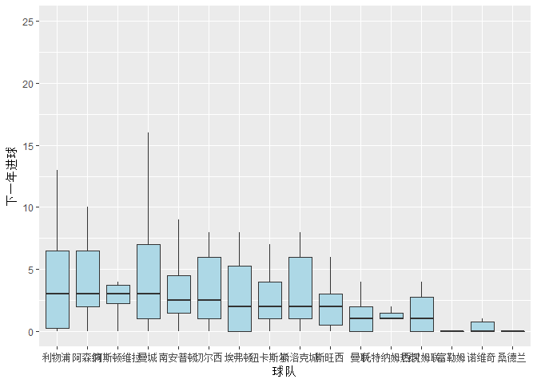

```r
#定性变量:球队，位置
cat = c(3,5,34)
datacat = soccer[,cat] #分类变量

group1 = aggregate(datacat$下一年进球,by = list(datacat$球队),data = datacat,"median")
SortName1 = group1$Group.1[order(group1$x,decreasing = T)]
datacat$球队 = factor(datacat$球队,levels = SortName1)
group2 = aggregate(datacat$下一年进球,by = list(datacat$位置),data = datacat,"median")
SortName2 = group2$Group.1[order(group2$x,decreasing = T)]
datacat$位置 = factor(datacat$位置,levels = SortName2)
#球队
p = ggplot(datacat)+aes_string("球队","下一年进球")+geom_boxplot(fill = I("lightblue"),outlier.size = NA,outlier.colour = NA)
p+ylim(0,25)
```

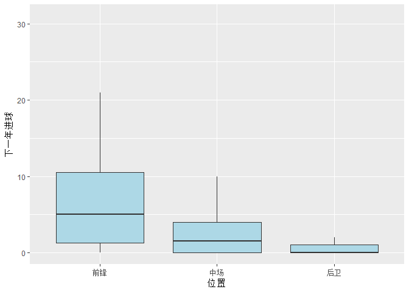

```r
#位置
p+aes_string("位置","下一年进球")
```

### （三）定量变量描述统计与特征选择（过滤法）

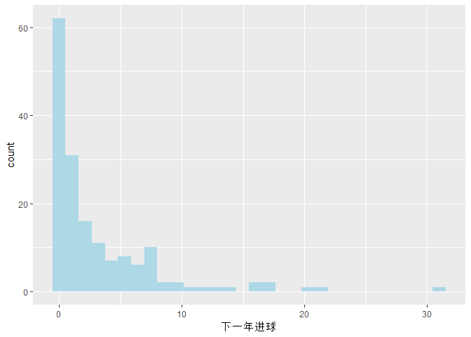

```r
#去除球员 球队 号码 位置，得到定量变量
datanum = soccer[,-c(cat[-3],1,4)]
#因变量分布
ggplot(datanum,aes_string("下一年进球"))+geom_histogram(fill = I("lightblue"))
```

```r
#删除0方差变量
dele0var = nearZeroVar(datanum,freqCut = 95/5)
colnames(datanum)[dele0var]
```

```
## [1] "头球争顶失败"
```

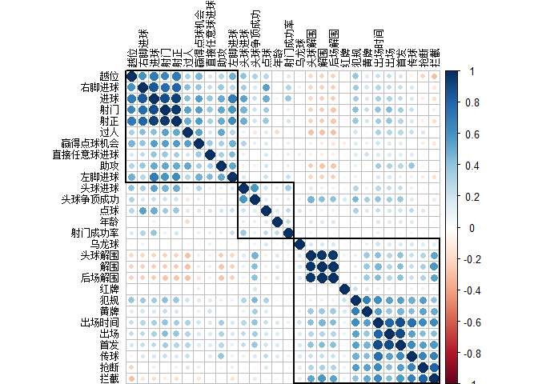

```r
datanum = datanum[,-dele0var]
#删除高相关度变量
corrplot(cor(datanum[,-dim(datanum)[2]]),order = "hclust",addrect = 3,tl.col = "black",tl.cex = 0.7,rect.col = "black")
```

```r
deleHighCor = findCorrelation(cor(datanum[,-dim(datanum)[2]]),0.85)
colnames(datanum)[deleHighCor]
```

```
## [1] "出场时间" "进球"     "射正"     "首发"     "解围"     "后场解围"
```

```r
datanum = datanum[,-deleHighCor]
summary(datanum)
```

```
##       年龄            出场            助攻             传球
##  Min.   :20.00   Min.   : 0.00   Min.   : 0.000   Min.   :   9.0
##  1st Qu.:25.00   1st Qu.:21.00   1st Qu.: 0.000   1st Qu.: 516.8
##  Median :27.00   Median :28.00   Median : 2.000   Median : 892.0
##  Mean   :27.49   Mean   :26.23   Mean   : 2.404   Mean   : 948.5
##  3rd Qu.:30.00   3rd Qu.:34.00   3rd Qu.: 4.000   3rd Qu.:1292.0
##  Max.   :40.00   Max.   :38.00   Max.   :12.000   Max.   :2774.0
##       过人             抢断             越位             犯规
##  Min.   :  0.00   Min.   :  1.00   Min.   : 0.000   Min.   : 0.00
##  1st Qu.:  9.00   1st Qu.: 19.25   1st Qu.: 0.000   1st Qu.:14.00
##  Median : 22.00   Median : 35.00   Median : 2.000   Median :23.00
##  Mean   : 32.33   Mean   : 41.01   Mean   : 5.651   Mean   :25.46
##  3rd Qu.: 47.50   3rd Qu.: 57.00   3rd Qu.: 6.000   3rd Qu.:34.75
##  Max.   :255.00   Max.   :146.00   Max.   :50.000   Max.   :82.00
##       红牌             黄牌             射门          射门成功率
##  Min.   :0.0000   Min.   : 0.000   Min.   :  0.00   Min.   :0.00000
##  1st Qu.:0.0000   1st Qu.: 1.000   1st Qu.: 14.00   1st Qu.:0.04348
##  Median :0.0000   Median : 3.000   Median : 23.50   Median :0.09281
##  Mean   :0.1687   Mean   : 3.392   Mean   : 34.98   Mean   :0.10072
##  3rd Qu.:0.0000   3rd Qu.: 5.000   3rd Qu.: 52.50   3rd Qu.:0.14286
##  Max.   :2.0000   Max.   :10.000   Max.   :187.00   Max.   :0.57143
##     头球进球         左脚进球         右脚进球      直接任意球进球
##  Min.   :0.0000   Min.   : 0.000   Min.   : 0.000   Min.   :0.0000
##  1st Qu.:0.0000   1st Qu.: 0.000   1st Qu.: 0.000   1st Qu.:0.0000
##  Median :0.0000   Median : 0.000   Median : 1.000   Median :0.0000
##  Mean   :0.6747   Mean   : 1.145   Mean   : 1.928   Mean   :0.1205
##  3rd Qu.:1.0000   3rd Qu.: 1.000   3rd Qu.: 3.000   3rd Qu.:0.0000
##  Max.   :5.0000   Max.   :18.000   Max.   :15.000   Max.   :2.0000
##       点球         赢得点球机会        拦截           头球解围
##  Min.   :0.0000   Min.   :0.000   Min.   :  1.00   Min.   :  0.00
##  1st Qu.:0.0000   1st Qu.:0.000   1st Qu.: 12.00   1st Qu.:  5.00
##  Median :0.0000   Median :0.000   Median : 27.50   Median : 15.00
##  Mean   :0.3133   Mean   :0.247   Mean   : 32.83   Mean   : 34.43
##  3rd Qu.:0.0000   3rd Qu.:0.000   3rd Qu.: 48.00   3rd Qu.: 43.75
##  Max.   :5.0000   Max.   :5.000   Max.   :139.00   Max.   :195.00
##   头球争顶成功        乌龙球         下一年进球
##  Min.   :  0.00   Min.   :0.0000   Min.   : 0.000
##  1st Qu.:  8.00   1st Qu.:0.0000   1st Qu.: 0.000
##  Median : 20.50   Median :0.0000   Median : 1.000
##  Mean   : 36.50   Mean   :0.1205   Mean   : 3.012
##  3rd Qu.: 50.75   3rd Qu.:0.0000   3rd Qu.: 4.000
##  Max.   :281.00   Max.   :2.0000   Max.   :31.000
```

### （四）降维

本案列采用主成分方法降维，进行主成分分析之前先标准化。

```r
#查看相关图
head(datanum[,-dim(datanum)[2]],3)
```

```
##   年龄 出场 助攻 传球 过人 抢断 越位 犯规 红牌 黄牌 射门 射门成功率
## 1   25   36    0  861    1   70    0   41    0    8   15 0.06666667
## 2   31   35    2 1018    9   59   16   64    0    6   78 0.12820513
## 3   24   26    1  634    1   33    2   10    0    5   20 0.05000000
##   头球进球 左脚进球 右脚进球 直接任意球进球 点球 赢得点球机会 拦截
## 1        1        0        0              0    0            1   73
## 2        1        3        6              0    0            0   31
## 3        1        0        0              0    0            0   29
##   头球解围 头球争顶成功 乌龙球
## 1      191           86      0
## 2       20           18      0
## 3       98           71      0
```

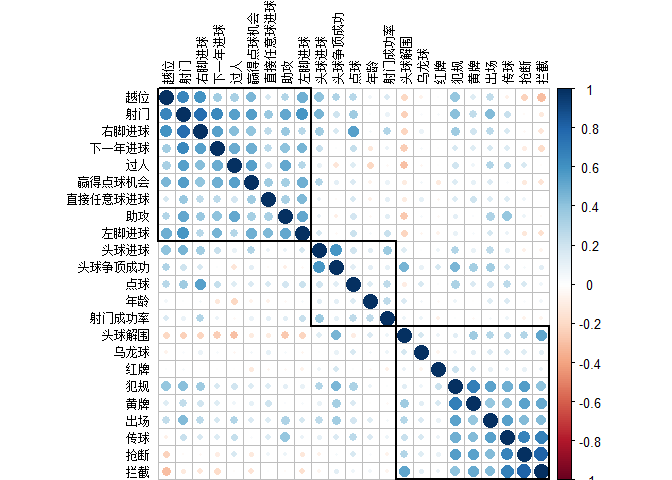

```r
corrplot(cor(datanum),order = "hclust"
         ,addrect = 3,tl.col = "black",tl.cex = 0.7,rect.col = "black")
```

```r
#标准化以消除量纲影响，同时保存各个指标变异程度的差异
datanum1 = data.frame(scale(datanum)) #标准化
```

```r
pca.fit=princomp(x = datanum1[,-dim(datanum1)[2]])
summary(pca.fit)
```

```
## Importance of components:
##                           Comp.1    Comp.2     Comp.3     Comp.4
## Standard deviation     2.2960269 1.9599731 1.45747298 1.21942885
## Proportion of Variance 0.2410768 0.1756716 0.09714098 0.06800086
## Cumulative Proportion  0.2410768 0.4167484 0.51388943 0.58189029
##                            Comp.5     Comp.6     Comp.7     Comp.8
## Standard deviation     1.08986378 1.02646682 0.97714130 0.93563964
## Proportion of Variance 0.05431827 0.04818272 0.04366326 0.04003305
## Cumulative Proportion  0.63620855 0.68439127 0.72805453 0.76808759
##                            Comp.9    Comp.10    Comp.11    Comp.12
## Standard deviation     0.90188020 0.79700092 0.74653966 0.73947923
## Proportion of Variance 0.03719625 0.02904819 0.02548633 0.02500653
## Cumulative Proportion  0.80528384 0.83433203 0.85981835 0.88482488
##                           Comp.13    Comp.14    Comp.15    Comp.16
## Standard deviation     0.69496727 0.66080861 0.60844976 0.51989110
## Proportion of Variance 0.02208667 0.01996884 0.01692976 0.01236022
## Cumulative Proportion  0.90691155 0.92688039 0.94381015 0.95617038
##                           Comp.17     Comp.18     Comp.19     Comp.20
## Standard deviation     0.49917873 0.455440205 0.445486049 0.370108816
## Proportion of Variance 0.01139498 0.009485587 0.009075482 0.006264124
## Cumulative Proportion  0.96756536 0.977050943 0.986126424 0.992390548
##                            Comp.21    Comp.22
## Standard deviation     0.334267437 0.23380493
## Proportion of Variance 0.005109632 0.00249982
## Cumulative Proportion  0.997500180 1.00000000
```

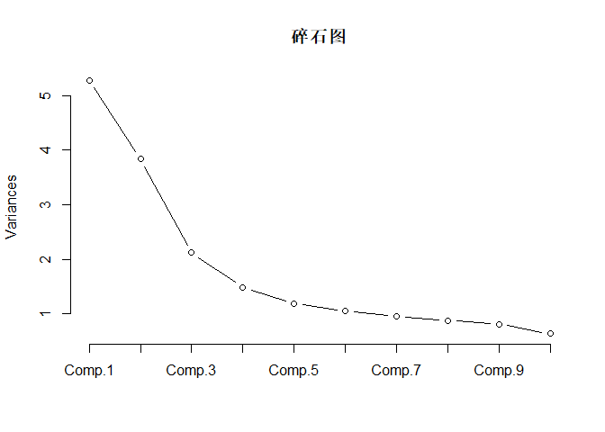

```r
plot(pca.fit,type="lines",main = "碎石图")
```

```r
cbind(round(pca.fit$loadings[,1:5],2))
```

```
##                Comp.1 Comp.2 Comp.3 Comp.4 Comp.5
## 年龄            -0.04   0.07   0.24   0.42  -0.17
## 出场            -0.28   0.20  -0.02  -0.01   0.07
## 助攻            -0.24  -0.14  -0.29   0.15   0.04
## 传球            -0.23   0.29  -0.21   0.19  -0.06
## 过人            -0.24  -0.14  -0.33  -0.16  -0.02
## 抢断            -0.14   0.39  -0.25   0.04  -0.10
## 越位            -0.27  -0.22   0.20  -0.18  -0.07
## 犯规            -0.30   0.22   0.06  -0.23  -0.19
## 红牌            -0.04   0.10   0.08  -0.34  -0.28
## 黄牌            -0.22   0.28   0.00  -0.19   0.06
## 射门            -0.37  -0.18  -0.01  -0.10  -0.02
## 射门成功率      -0.11  -0.06   0.25   0.50  -0.03
## 头球进球        -0.22  -0.04   0.42  -0.03   0.11
## 左脚进球        -0.23  -0.22  -0.09   0.13   0.25
## 右脚进球        -0.31  -0.16   0.07   0.05  -0.30
## 直接任意球进球  -0.19  -0.09  -0.16   0.13   0.36
## 点球            -0.22  -0.01   0.06   0.27  -0.44
## 赢得点球机会    -0.24  -0.20  -0.04  -0.08   0.37
## 拦截            -0.09   0.43  -0.16   0.08   0.07
## 头球解围         0.00   0.34   0.25   0.04   0.38
## 头球争顶成功    -0.16   0.15   0.47  -0.20   0.17
## 乌龙球          -0.06   0.10   0.02   0.30   0.16
```

```r
head(pca.fit$scores[,1:5])
```

```
##          Comp.1     Comp.2    Comp.3     Comp.4     Comp.5
## [1,] -0.3712302  3.7165286 1.1914016 -1.1290521  2.3376567
## [2,] -2.3487870  0.3571175 0.6098669 -0.1800450 -1.0852680
## [3,]  1.4453700  0.8050132 1.0040075 -0.8268925  1.2124753
## [4,]  0.7497051  2.9871533 1.1354984 -0.6997100  1.5168513
## [5,] -2.9837051 -0.7331868 2.8054803 -1.5774289  2.1847120
## [6,]  0.6161167 -0.5490351 2.2603514 -1.7172680 -0.8201988
```

```r
newfeature<-pca.fit$scores[,1:5]
```

选取前五个主成分对因变量作回归分析，第一第二主成分显著影响下一赛季进球数。 通过对第一第二主成分各变量贡献进行排序，可以发现，射门、右脚进球、犯规、出场、越位、助攻、拦截、抢断、头球解围、传球、黄牌、左脚进球等变量对下一赛季进球数有明显影响，后续分析中（如机器学习）应予以适当关注。

```r
model1 = lm(log(datanum1[,dim(datanum1)[2]]+1)~newfeature)
summary(model1)
```

```
##
## Call:
## lm(formula = log(datanum1[, dim(datanum1)[2]] + 1) ~ newfeature)
##
## Residuals:
##      Min       1Q   Median       3Q      Max
## -1.44570 -0.44660 -0.07649  0.39589  1.48575
##
## Coefficients:
##                  Estimate Std. Error t value Pr(>|t|)
## (Intercept)      -0.31701    0.04629  -6.849 1.51e-10 ***
## newfeatureComp.1 -0.15810    0.02016  -7.843 5.88e-13 ***
## newfeatureComp.2 -0.11435    0.02362  -4.842 3.01e-06 ***
## newfeatureComp.3 -0.07835    0.03176  -2.467   0.0147 *
## newfeatureComp.4 -0.02934    0.03796  -0.773   0.4407
## newfeatureComp.5 -0.02368    0.04247  -0.558   0.5778
## ---
## Signif. codes:  0 '***' 0.001 '**' 0.01 '*' 0.05 '.' 0.1 ' ' 1
##
## Residual standard error: 0.5964 on 160 degrees of freedom
## Multiple R-squared:  0.3649, Adjusted R-squared:  0.3451
## F-statistic: 18.39 on 5 and 160 DF,  p-value: 2.104e-14
```

```r
#第一第二主成分依赖的变量排序
head(as.matrix(pca.fit$loadings[,1][order(abs(pca.fit$loadings[,1]),decreasing = T)]))
```

```
##                [,1]
## 射门     -0.3654565
## 右脚进球 -0.3114417
## 犯规     -0.2951304
## 出场     -0.2793970
## 越位     -0.2726721
## 助攻     -0.2443835
```

```r
head(as.matrix(pca.fit$loadings[,2][order(abs(pca.fit$loadings[,2]),decreasing = T)]))
```

```
##                [,1]
## 拦截      0.4318151
## 抢断      0.3867268
## 头球解围  0.3375613
## 传球      0.2926836
## 黄牌      0.2823873
## 左脚进球 -0.2246832
```